# Forecasting demographic variables

The library `demography`

Pedro Delicado

Simposio de Estadística, Ibagué, Colombia. 2023

# 1 Library `demography`. An introduction

```r
library(demography)
```

This library was developed by [**Rob Hyndman**](https://robjhyndman.com/) and his research team.

From the package’s help:

> **Forecasting mortality and fertility data**  
> *Description*  
> Functions for demographic analysis including lifetable calculations, Lee-Carter modelling and  
> functional data analysis of mortality rates.

> **Author(s)**  
> **Rob J Hyndman** with contributions from Heather Booth, Leonie Tickle, John Maindonald, Simon Wood and the R Core Team.

> Maintainer: [**Rob Hyndman**](https://robjhyndman.com/)

## 1.1 An example: French mortality data

```r
class(fr.mort)
```

```
## [1] "demogdata"
```

```r
#help(demogdata)
names(fr.mort)
```

```
## [1] "type"   "label"  "lambda" "year"   "age"    "rate"   "pop"
```

```r
names(fr.mort$rate)
```

```
## [1] "total"  "female" "male"
```

```r
dim(fr.mort$rate$total)
```

```
## [1] 111 191
```

We plot the mortality rate function corresponding to an specific calendar year:

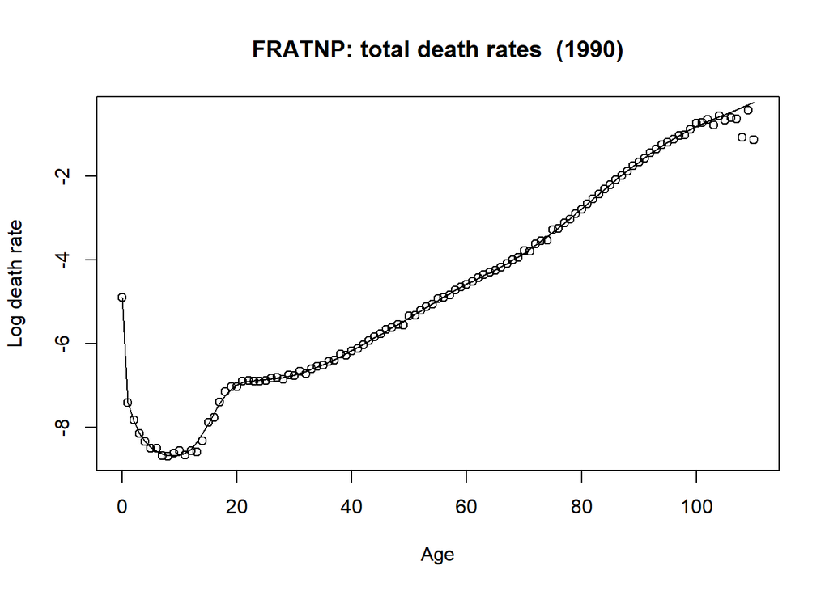

```r
plot(fr.mort,years=1990,type='p',pch=1)
lines(fr.sm,years=1990)
```

Now We plot the set of mortality rate functions, one for each calendar year:

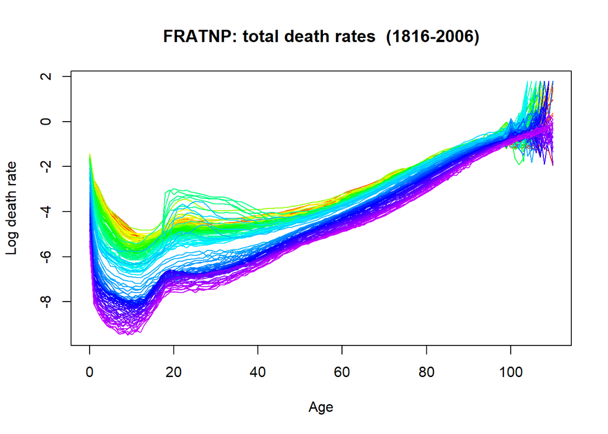

```r
plot(fr.mort)
```

And the smoothed version:

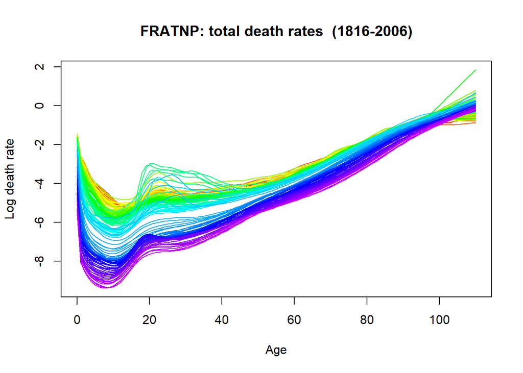

```r
plot(fr.sm)
```

## 1.2 Fitting a model for demographic data

Let $y_t(s)$ be a demographic characteristic $y$ corresponding to age $s$ measured at calendar year $t$, in a given population (that is, a country or region of interest).

Observations of $y_t(s)$ are done for years $t=t_0, t_0+1,\ldots, t_f$, and for ages $s\in \{s_1,\ldots,s_n\}\subset [s_0,s_f]$. It is assumed that
$$y_t(s_i)=m_t(s_i) + \varepsilon_{t,s_i},$$
where $m_t(s_i)$ is a *random smooth function* of $s$ (and usually also in $t$).

That is, $m_t(s_i)$ is a realization of a *functional random variable*.

It is assumed that $m_t(s_i)$ verify the sufficient conditions for admitting a Karhunen-Loève decomposition
$$m_t(s)=\mu(s) + \sum_{k=1}^{\infty} \beta_{t,k} \phi_k(s), \,\,
s\in[s_0,s_f].$$

For $t=t_0,\ldots,t_f$, the data $y_t(s_i)$, $i=1,\ldots,n$, are smoothed to estimate the function $m_t(s)$, $s\in [s_0,s_f]$. Let $\tilde{m}_t(s)$ be the smoothed functions.

Then Functional Principal Components Analysis is applied to the functional data set $\{\tilde{m}_t(s): t=t_0,\ldots,t_f\}$ to obtain an estimation of the truncated Karhunen-Loève decomposition:
$$\tilde{m}_t(s)=\hat{\mu}(s) + \sum_{k=1}^{K} \hat{\beta}_{t,k}
\hat{\phi}_k(s), \,\, s\in[s_0,s_f].$$

```r
france.fit <- fdm(fr.mort,order=2)
france.fit
```

```
## Functional demographic model
##
## Call: fdm(data = fr.mort, order = 2)
##
## Region: FRATNP
## Data type: mortality
## Years in fit: 1816 - 2006
## Ages in fit: 0 - 110
##
## Order: 2
## Percentage variation due to basis functions: 93.8% 2.3%
```

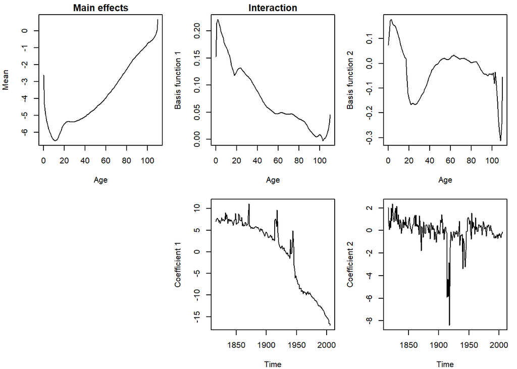

```r
par(mar=c(4,4,1.5,1))
plot(france.fit)
```

```r
class(france.fit)
```

```
## [1] "fdm"  "ftsm"
```

```r
names(france.fit)
```

```
##  [1] "label"     "age"       "year"      "total"     "pop"       "fitted"
##  [7] "residuals" "basis"     "coeff"     "mean.se"   "varprop"   "weights"
## [13] "wt"        "obs.var"   "v"         "type"      "y"         "basis2"
## [19] "coeff2"    "lambda"    "call"
```

The element `basis` of the fitted model has the fitted mean as a first column. The following columns are the functional principal components used to fit the data:

```r
dim(france.fit$basis)
```

```
## [1] 111   3
```

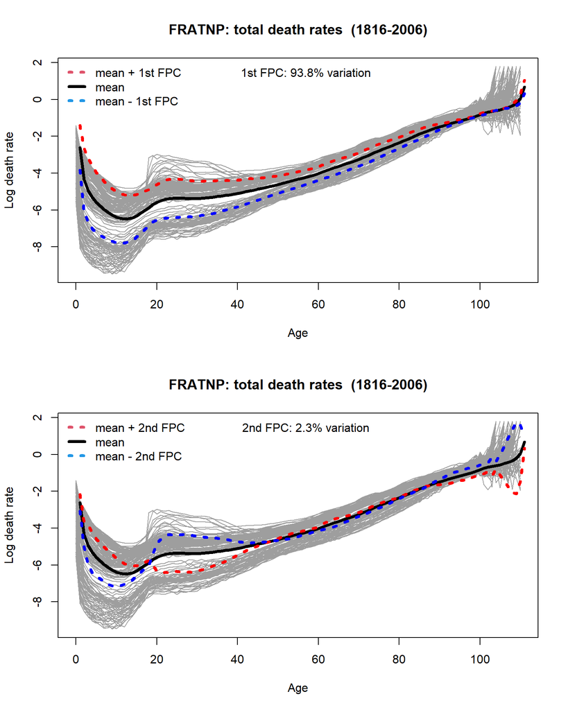

```r
par(mfrow=c(2,1))
plot(fr.mort,col=8)
lines(france.fit$basis[,1],lwd=4)
eig_val_1 <- var(france.fit$coeff[,2])
lines(france.fit$basis[,1]+sqrt(eig_val_1)*france.fit$basis[,2],lwd=4,col="red",lty=3)
lines(france.fit$basis[,1]-sqrt(eig_val_1)*france.fit$basis[,2],lwd=4,col="blue",lty=3)
legend("topleft",c("mean + 1st FPC ", "mean", "mean - 1st FPC "),
       lty=c(3,1,3), col=c(2,1,4), lwd=4, bty="n",seg.len = 1.5)
legend("top",paste0("1st FPC: ",round(100*france.fit$varprop[1],1),"% variation"), bty="n")

plot(fr.mort,col=8)
lines(france.fit$basis[,1],lwd=4)
eig_val_2 <- var(france.fit$coeff[,3])
cte=5
lines(france.fit$basis[,1]+cte*sqrt(eig_val_2)*france.fit$basis[,3],lwd=4,col="red",lty=3)
lines(france.fit$basis[,1]-cte*sqrt(eig_val_2)*france.fit$basis[,3],lwd=4,col="blue",lty=3)
legend("topleft",c("mean + 2nd FPC ", "mean", "mean - 2nd FPC "),
       lty=c(3,1,3), col=c(2,1,4), lwd=4, bty="n",seg.len = 1.5)
legend("top",paste0("2nd FPC: ",round(100*france.fit$varprop[2],1),"% variation"), bty="n")
```

The element `coeff` of the fitted model has first column equal to one. The following columns are the scores of each calendar year at the corresponding functional principal components used to fit the data:

```r
dim(france.fit$coeff)
```

```
## [1] 191   3
```

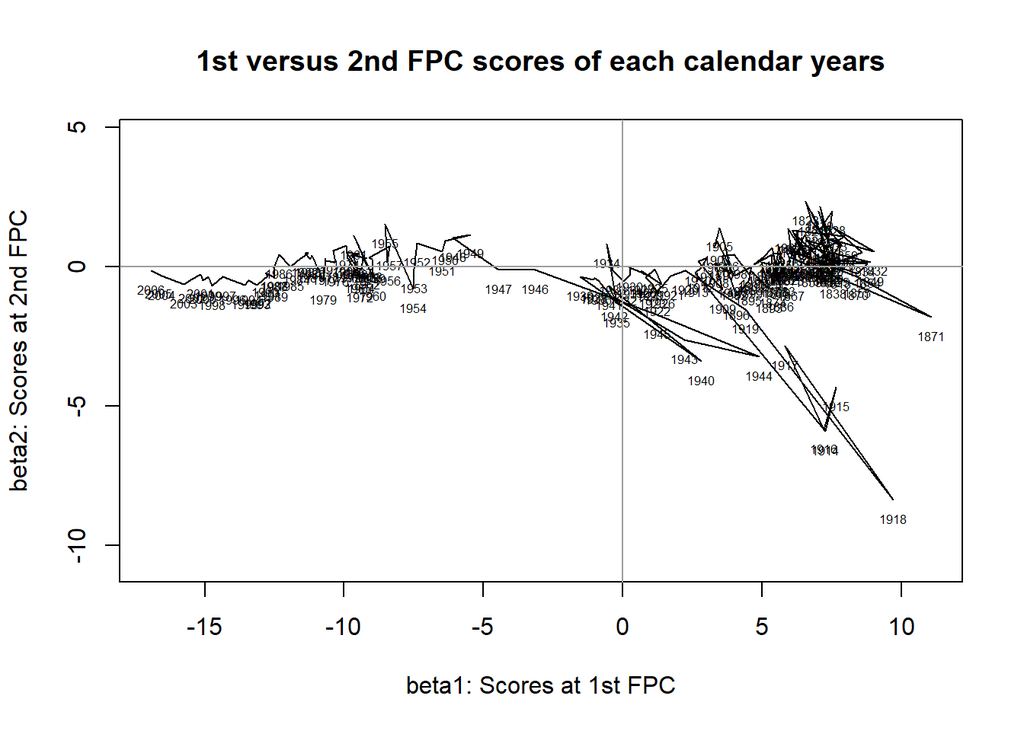

```r
plot(france.fit$coeff[,2],france.fit$coeff[,3],type="l",as=1,
     main="1st versus 2nd FPC scores of each calendar years",
     xlab="beta1: Scores at 1st FPC", ylab="beta2: Scores at 2nd FPC")
text(france.fit$coeff[,2],france.fit$coeff[,3],france.fit$year,pos=1,cex=.5)
abline(v=0,h=0,col=8)
```

Internally, these scores are stored as time series:

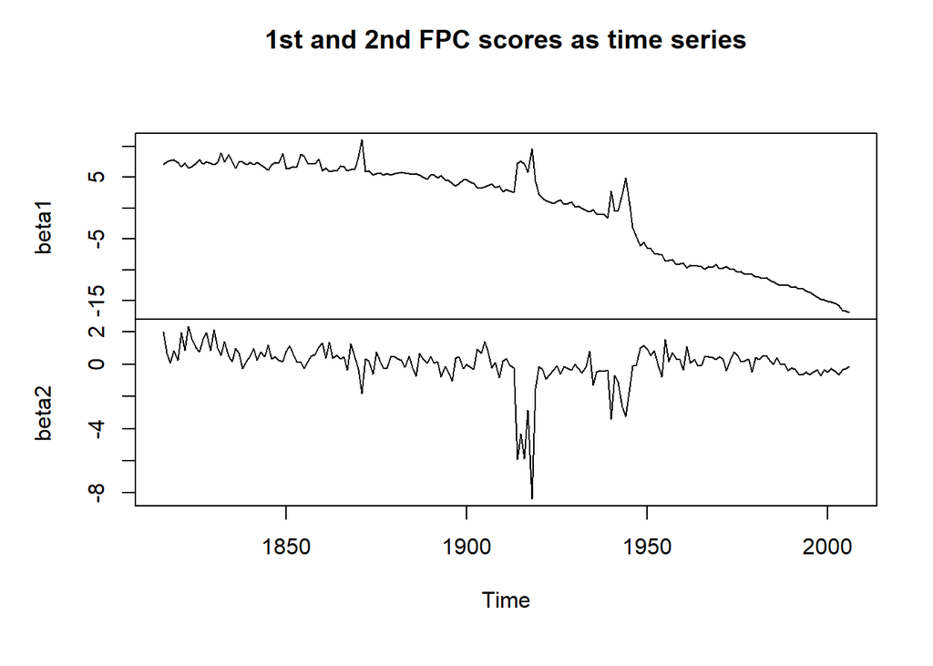

```r
plot(france.fit$coeff[,2:3], main="1st and 2nd FPC scores as time series")
```

## 1.3 Forecasting of a demographic variable

We write again the estimation of the truncated Karhunen-Loève decomposition:
$$\tilde{m}_t(s)=\hat{\mu}(s) + \sum_{k=1}^{K} \hat{\beta}_{t,k}
\hat{\phi}_k(s), \,\, s\in[s_0,s_f].$$
To forecast $y_t(s)$, we need forecasts of $\hat{\beta}_{t,k}$, for $t\ge t_f+1$ and $k=1,\dots,K$.

That is, we have to forecast the time series of the scores in the FPCs.

The library `dmography` calls the function `auto.arima` from the librry `forecast`, also developed and maintained by [**Rob Hyndman**](https://robjhyndman.com/).

```r
france.fcast <- forecast(france.fit,50)
models(france.fcast)
```

```
##
## -- Coefficient 1 --
## Series: xx[, i]
## ARIMA(1,1,1) with drift
##
## Coefficients:
##          ar1      ma1    drift
##       0.6383  -0.8145  -0.1265
## s.e.  0.1481   0.1120   0.0411
##
## sigma^2 = 1.206:  log likelihood = -285.97
## AIC=579.95   AICc=580.16   BIC=592.93
##
## -- Coefficient 2 --
## Series: xx[, i]
## ARIMA(2,1,1)
##
## Coefficients:
##          ar1     ar2      ma1
##       0.3818  0.2926  -0.9679
## s.e.  0.0758  0.0745   0.0280
##
## sigma^2 = 0.9067:  log likelihood = -259.4
## AIC=526.79   AICc=527.01   BIC=539.78
```

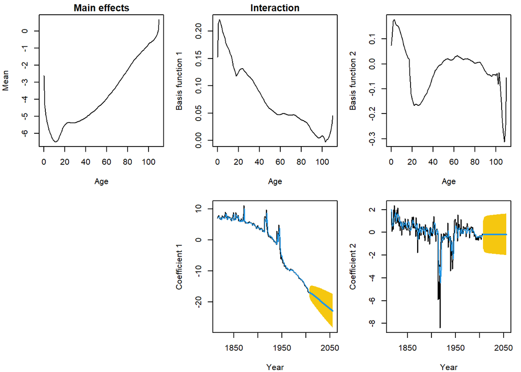

```r
par(mar=c(4,4,1.5,1))
plot(france.fcast,'c')
```

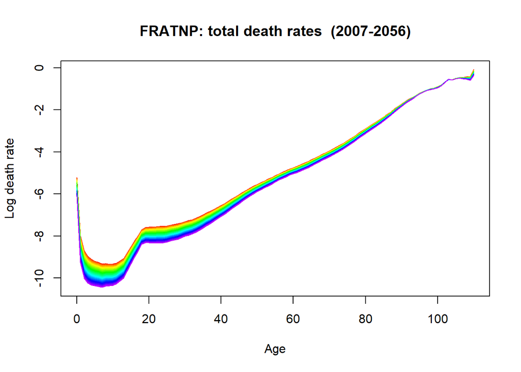

```r
plot(france.fcast)
```

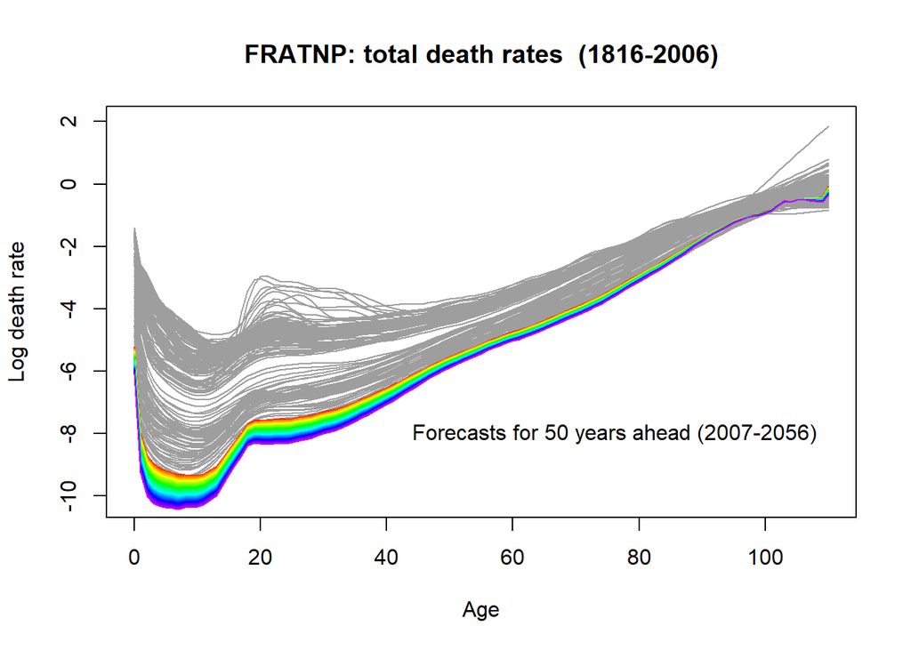

```r
plot(fr.sm,col=8,ylim=c(-10.2,2))
lines(france.fcast)
text(42,-8,"Forecasts for 50 years ahead (2007-2056)",cex=1,pos=4)
```

# 2 Working with population pyrmids in library `demography`

```r
load("Smoothed_Poulation_Pyramids.RData")
# PopPyrSm, PopPyrRelSm, Year, egAge.1, Country
```

## 2.1 Colombia, absolute population pyramids

We start transforming a data set of population pyramids into a `demogdata` object. Function `demogdata` creates the basic objects for library `demography`. Unfortunately, the library was designed to work with only three types of demographic data: either **mortality**, **fertility** or **migration**.

We will use this library for **population pyramids**, and more specifically with **age-symmetric population histogram**. Even though we must specify one of the three types of demographic data the library `demography` is expecting.

In this case we state `"mortality"`, but other choices are also valid. It is important to specify `lambda=1` because this parameter indicates which Box-Cox transformation is applied to the data before start any analysis. For mortality data, the default value is `lambda=0`, meaning logarithm transformation. For `lambda=1` there is no transformation.

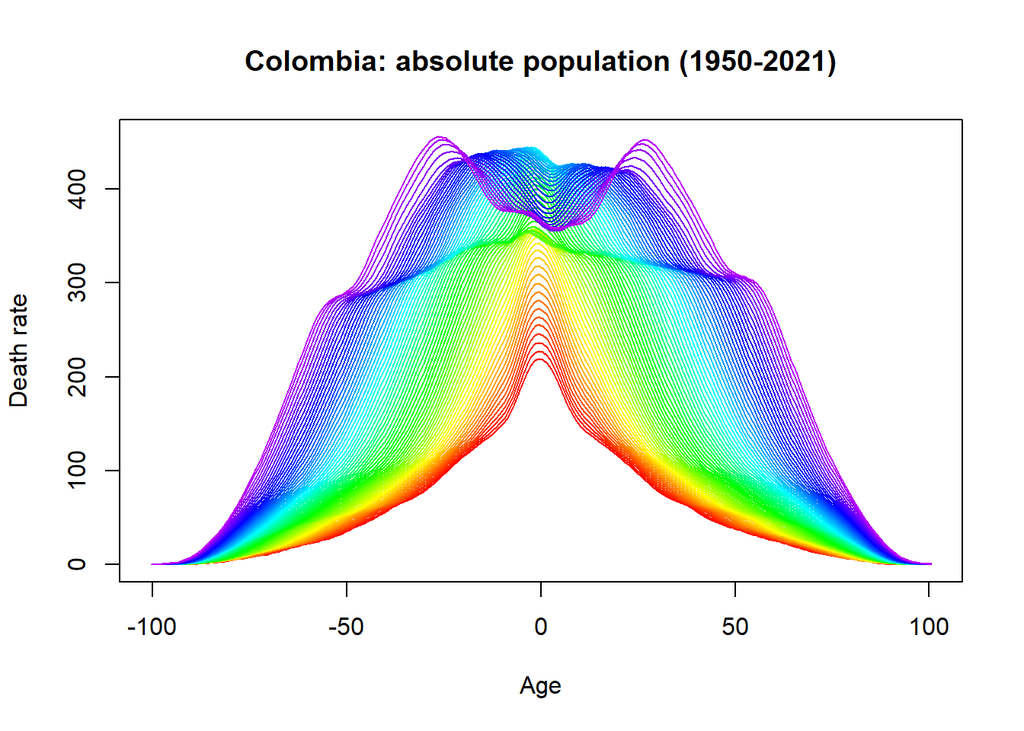

```r
ctr <- 'CO'
ppDemog <- demogdata(data=t(PopPyrSm[ctr,,]),
                     pop=t(PopPyrSm[ctr,,]),
                     ages=egAge.1, years=Year,
                     type= "mortality", label=Country[ctr,1],
                     name="Total", lambda=1)
plot(ppDemog, datatype = "rate", # It is possible to use datatype="pop"
     main=paste0(Country[ctr,1],": absolute population (",Year[1],"-", rev(Year)[1],")"))
```

### 2.1.1 Modeling and forecasting popultion pyramids

```r
ppDemog.fit <- fdm(ppDemog, order=2)
ppDemog.fit
```

```
## Functional demographic model
##
## Call: fdm(data = ppDemog, order = 2)
##
## Region: Colombia
## Data type: mortality
## Years in fit: 1950 - 2021
## Ages in fit: -100.5 - 100.5
##
## Order: 2
## Percentage variation due to basis functions: 91.1% 7.2%
```

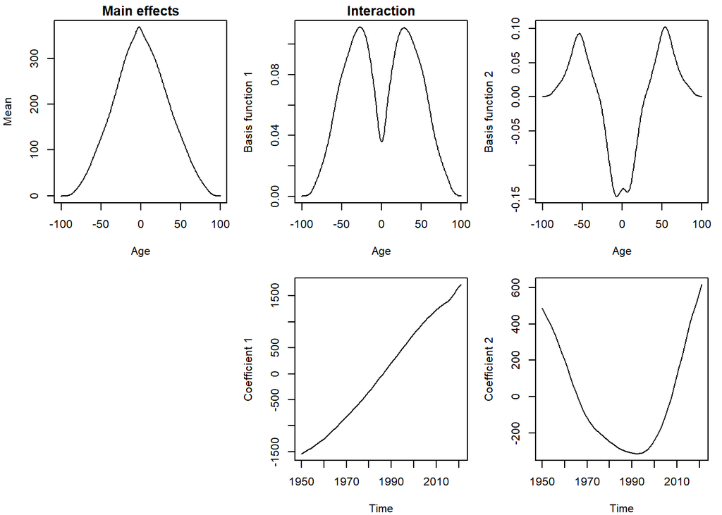

```r
par(mar=c(4,4,1.5,1))
plot(ppDemog.fit)
```

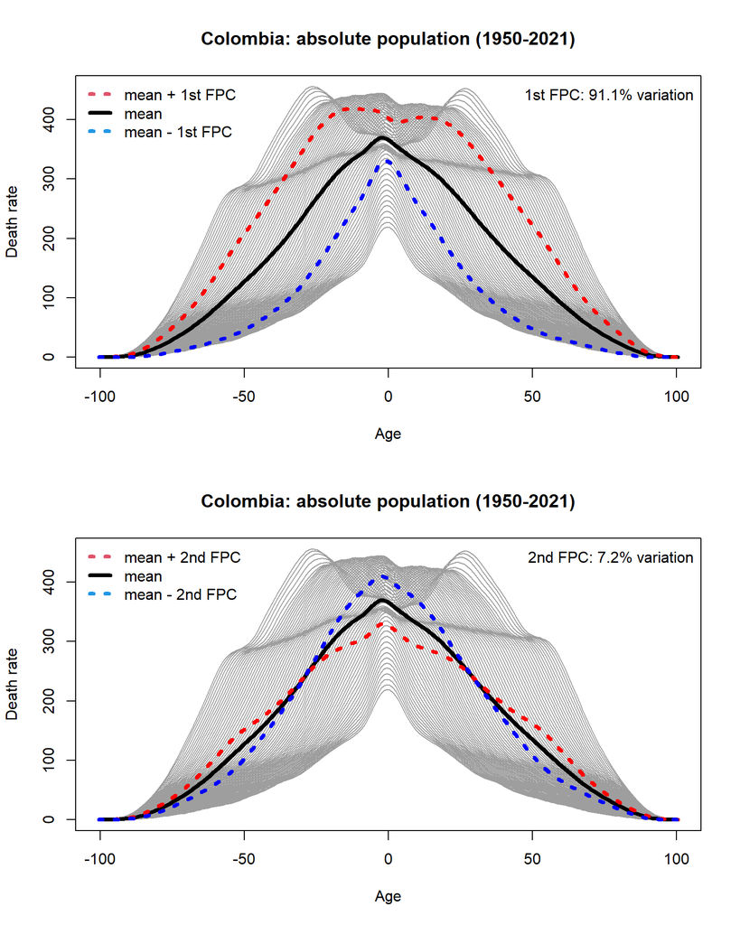

```r
par(mfrow=c(2,1))
plot(ppDemog,col=8,
     main=paste0(Country[ctr,1],": absolute population (",Year[1],"-", rev(Year)[1],")"))
lines(ppDemog$age, 1+ppDemog.fit$basis[,1],lwd=4)
eig_val_1 <- var(ppDemog.fit$coeff[,2])
lines(ppDemog$age, 1+ppDemog.fit$basis[,1]+sqrt(eig_val_1)*ppDemog.fit$basis[,2],lwd=4,col="red",lty=3)
lines(ppDemog$age, 1+ppDemog.fit$basis[,1]-sqrt(eig_val_1)*ppDemog.fit$basis[,2],lwd=4,col="blue",lty=3)
legend("topleft",c("mean + 1st FPC ", "mean", "mean - 1st FPC "),
       lty=c(3,1,3), col=c(2,1,4), lwd=4, bty="n",seg.len = 1.5)
legend("topright",paste0("1st FPC: ",round(100*ppDemog.fit$varprop[1],1),"% variation"), bty="n")


plot(ppDemog,col=8,
     main=paste0(Country[ctr,1],": absolute population (",Year[1],"-", rev(Year)[1],")"))
lines(ppDemog$age, 1+ppDemog.fit$basis[,1],lwd=4)
eig_val_2 <- var(ppDemog.fit$coeff[,3])
cte=1
lines(ppDemog$age, 1+ppDemog.fit$basis[,1]+cte*sqrt(eig_val_2)*ppDemog.fit$basis[,3],lwd=4,col="red",lty=3)
lines(ppDemog$age, 1+ppDemog.fit$basis[,1]-cte*sqrt(eig_val_2)*ppDemog.fit$basis[,3],lwd=4,col="blue",lty=3)
legend("topleft",c("mean + 2nd FPC ", "mean", "mean - 2nd FPC "),
       lty=c(3,1,3), col=c(2,1,4), lwd=4, bty="n",seg.len = 1.5)
legend("topright",paste0("2nd FPC: ",round(100*ppDemog.fit$varprop[2],1),"% variation"), bty="n")
```

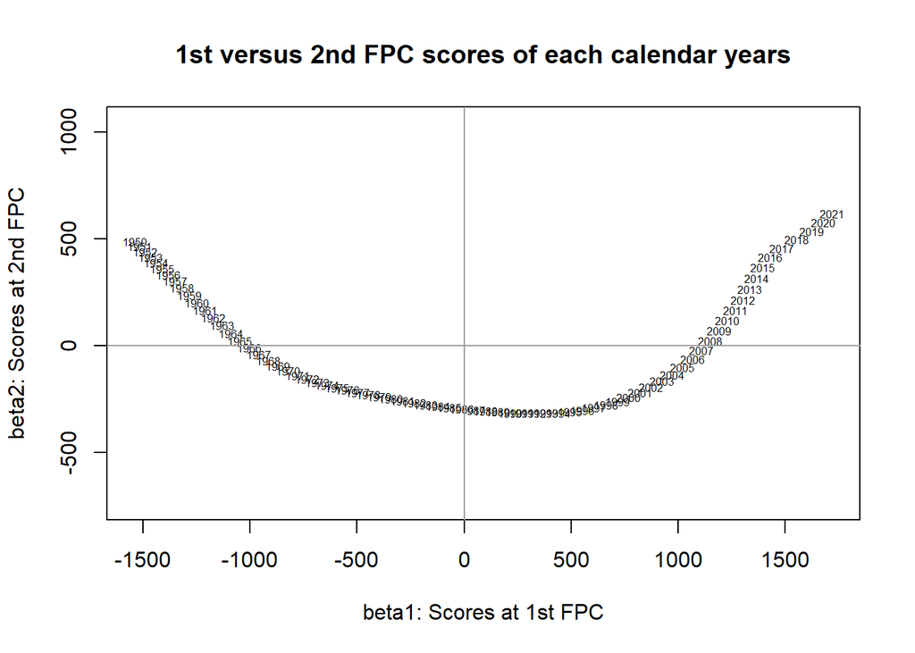

```r
plot(ppDemog.fit$coeff[,2],ppDemog.fit$coeff[,3],type="l",as=1,cex=.5,
     main="1st versus 2nd FPC scores of each calendar years",
     xlab="beta1: Scores at 1st FPC", ylab="beta2: Scores at 2nd FPC")
abline(v=0,h=0,col=8)
```

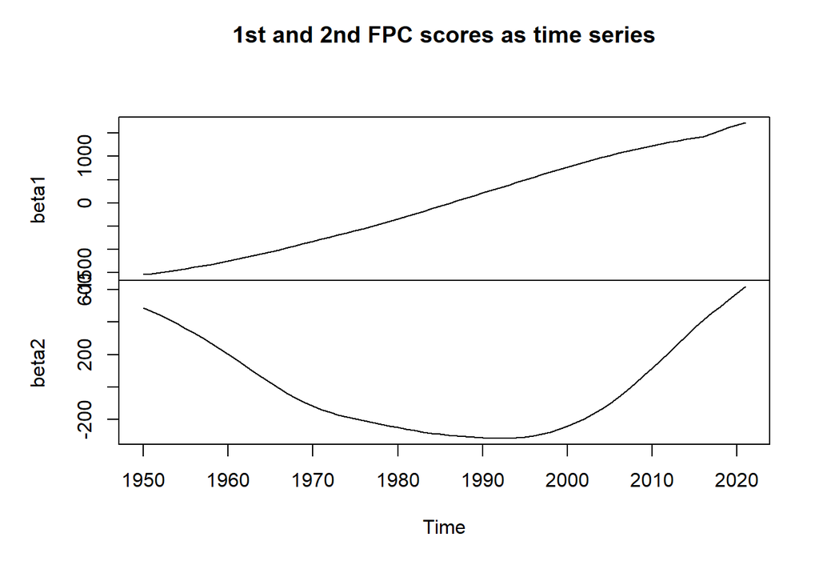

```r
plot(ppDemog.fit$coeff[,2:3], main="1st and 2nd FPC scores as time series")
```

Now, forecasts are computed for a horizon of 20 years:

```r
if (!exists("horiz")) horiz <- 20
ppDemog.fcast <- forecast(ppDemog.fit,h=horiz)
models(ppDemog.fcast)
```

```
##
## -- Coefficient 1 --
## Series: xx[, i]
## ARIMA(2,2,1)
##
## Coefficients:
##          ar1      ar2     ma1
##       0.8378  -0.6544  0.7752
## s.e.  0.1023   0.1077  0.0953
##
## sigma^2 = 3.601:  log likelihood = -143.79
## AIC=295.57   AICc=296.19   BIC=304.57
##
## -- Coefficient 2 --
## Series: xx[, i]
## ARIMA(1,2,2)
##
## Coefficients:
##          ar1     ma1     ma2
##       0.8192  1.2236  0.3069
## s.e.  0.0753  0.1292  0.1338
##
## sigma^2 = 0.2375:  log likelihood = -48.75
## AIC=105.49   AICc=106.11   BIC=114.49
```

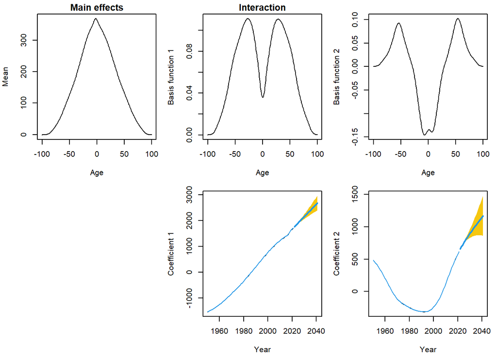

```r
par(mar=c(4,4,1.5,1))
plot(ppDemog.fcast,'c')
```

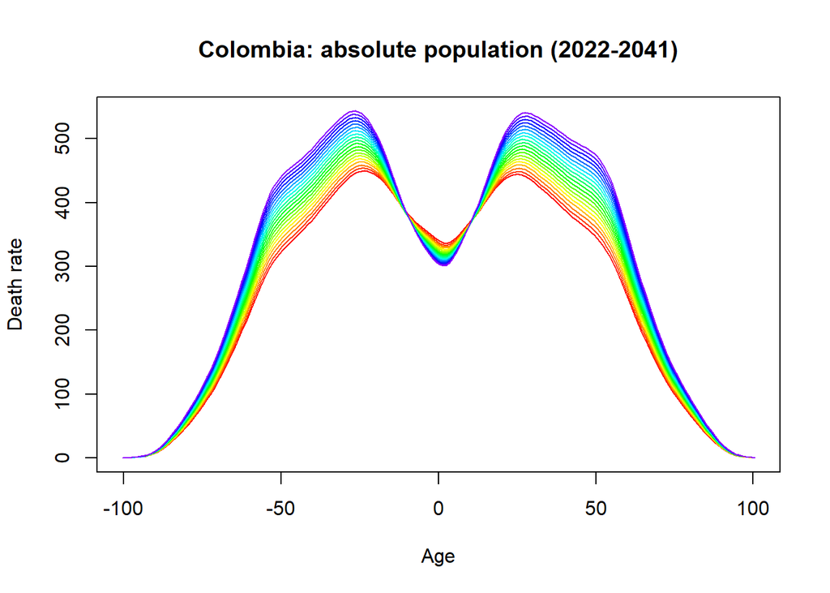

```r
plot(ppDemog.fcast,
     main=paste0(Country[ctr,1],": absolute population (",rev(Year)[1]+1,"-", rev(Year)[1]+horiz,")"))
```

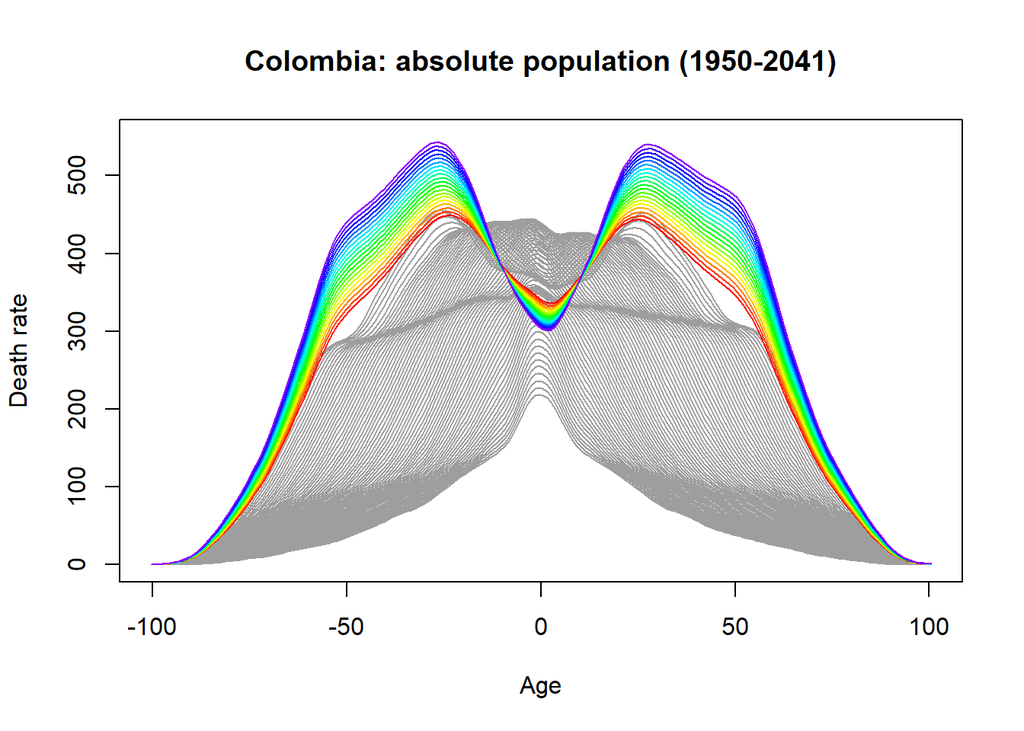

```r
plot(ppDemog, datatype = "rate", col=8,
     main=paste0(Country[ctr,1],
                 ": absolute population (",Year[1],"-",
                 rev(Year)[1]+horiz,")"),
     ylim=c(0,550))
plot(ppDemog.fcast,add=TRUE)
```

### 2.1.2 Ploting results as population pyramids

We plot now as population pyramids the modeling and forecasting results.

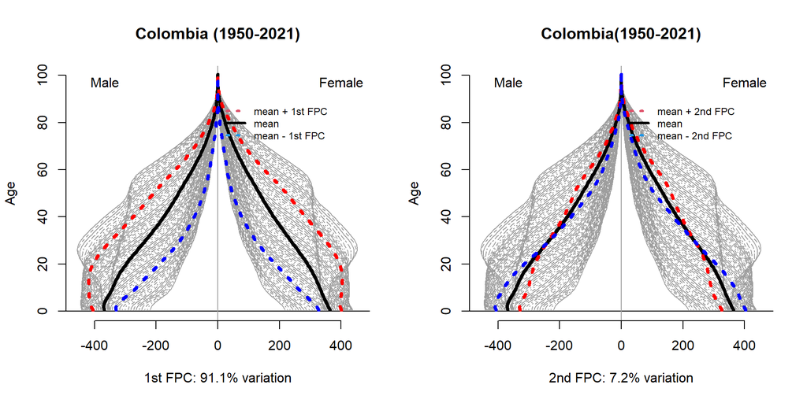

```r
Age.1 <- ppDemog$age[ppDemog$age>0]
par(mfrow=c(1,2))
matplot_pop_pyr_1y(Age.1, t(ppDemog$rate$Total),col=8,
     main=paste0(Country[ctr,1]," (",Year[1],"-", rev(Year)[1],")"))
lines_pop_pyr(Age.1, 1+ppDemog.fit$basis[,1],lwd=4)
eig_val_1 <- var(ppDemog.fit$coeff[,2])
lines_pop_pyr(Age.1, 1+ppDemog.fit$basis[,1]+sqrt(eig_val_1)*ppDemog.fit$basis[,2],lwd=4,col="red",lty=3)
lines_pop_pyr(Age.1, 1+ppDemog.fit$basis[,1]-sqrt(eig_val_1)*ppDemog.fit$basis[,2],lwd=4,col="blue",lty=3)
legend(-.011, 90,c("mean + 1st FPC ", "mean", "mean - 1st FPC "),
       lty=c(3,1,3), col=c(2,1,4), lwd=3, bty="n",seg.len = 2, cex=.75)
title(xlab=paste0("1st FPC: ",round(100*ppDemog.fit$varprop[1],1),"% variation"), bty="n")

matplot_pop_pyr_1y(Age.1, t(ppDemog$rate$Total),col=8,
     main=paste0(Country[ctr,1],"(",Year[1],"-", rev(Year)[1],")"))
lines_pop_pyr(Age.1, 1+ppDemog.fit$basis[,1],lwd=4)
eig_val_2 <- var(ppDemog.fit$coeff[,3])
cte=1
lines_pop_pyr(Age.1, 1+ppDemog.fit$basis[,1]+cte*sqrt(eig_val_2)*ppDemog.fit$basis[,3],lwd=4,col="red",lty=3)
lines_pop_pyr(Age.1, 1+ppDemog.fit$basis[,1]-cte*sqrt(eig_val_2)*ppDemog.fit$basis[,3],lwd=4,col="blue",lty=3)
legend(-.011, 90,c("mean + 2nd FPC ", "mean", "mean - 2nd FPC "),
       lty=c(3,1,3), col=c(2,1,4), lwd=3, bty="n",seg.len = 2, cex=.75)

title(xlab=paste0("2nd FPC: ",round(100*ppDemog.fit$varprop[2],1),"% variation"), bty="n")
```

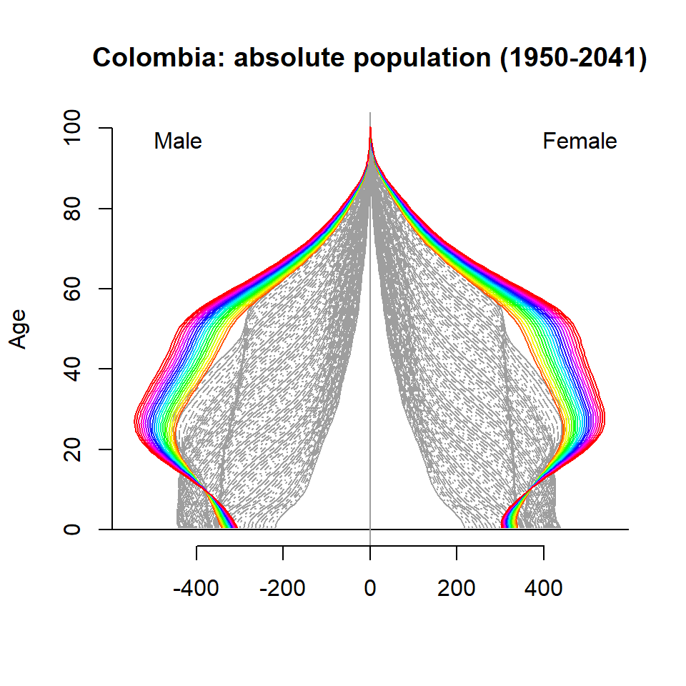

```r
matplot_pop_pyr_1y(Age.1,t(ppDemog$rate$Total), datatype = "rate", col=8,
     main=paste0(Country[ctr,1],
                 ": absolute population (",
                 Year[1],"-", rev(Year)[1]+horiz,")"),
     xlim=550)
col <- rainbow(horiz, start=0, end=1)
for (i in (1:horiz)){
  lines_pop_pyr(Age.1,ppDemog.fcast$rate$total[,i], col=col[i%%length(col)+1])
}
```

## 2.2 Colombia, relative population pyramids

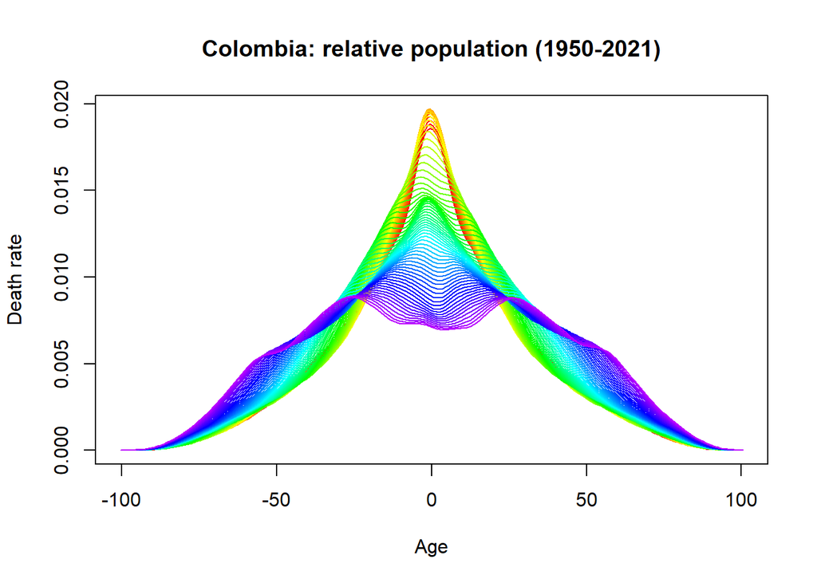

```r
ctr <- 'CO'
ppDemog <- demogdata(data=t(PopPyrRelSm[ctr,,]),
                     pop=t(PopPyrSm[ctr,,]),
                     ages=egAge.1, years=Year,
                     type= "mortality", label=Country[ctr,1],
                     name="Total", lambda=1)
plot(ppDemog, datatype = "rate", # It is possible to use datatype="pop"
     main=paste0(Country[ctr,1],": relative population (",Year[1],"-", rev(Year)[1],")"))
```

### 2.2.1 Modeling and forecasting popultion pyramids

```r
ppDemog.fit <- fdm(ppDemog, order=2)
ppDemog.fit
```

```
## Functional demographic model
##
## Call: fdm(data = ppDemog, order = 2)
##
## Region: Colombia
## Data type: mortality
## Years in fit: 1950 - 2021
## Ages in fit: -100.5 - 100.5
##
## Order: 2
## Percentage variation due to basis functions: 89.3% 6.2%
```

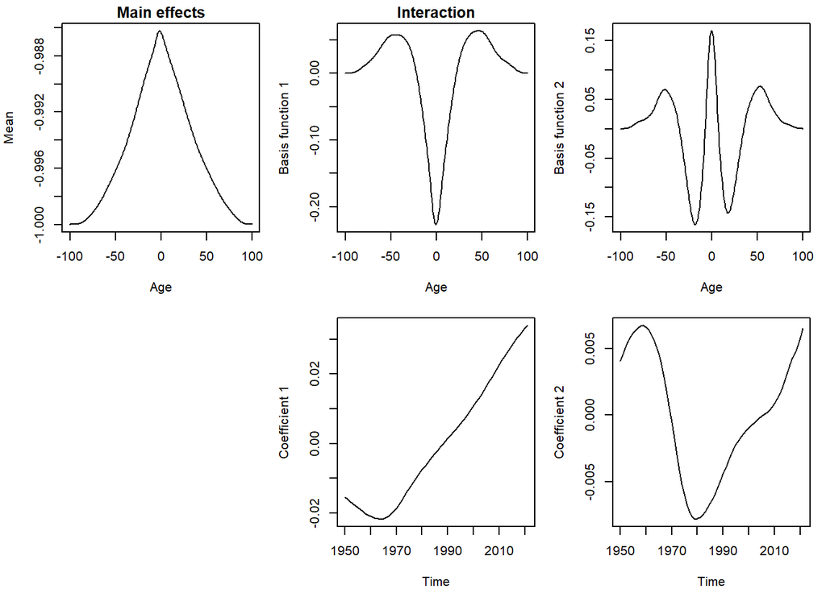

```r
par(mar=c(4,4,1.5,1))
plot(ppDemog.fit)
```

Note in the previous graphics that the **Main effects** are negative in this example. There is no clear reason for this. In fact, here the true estimation of the mean is not the element `basis[,1]` of the fitted model (as in the previous example) but instead it is `1+basis[,1]`.

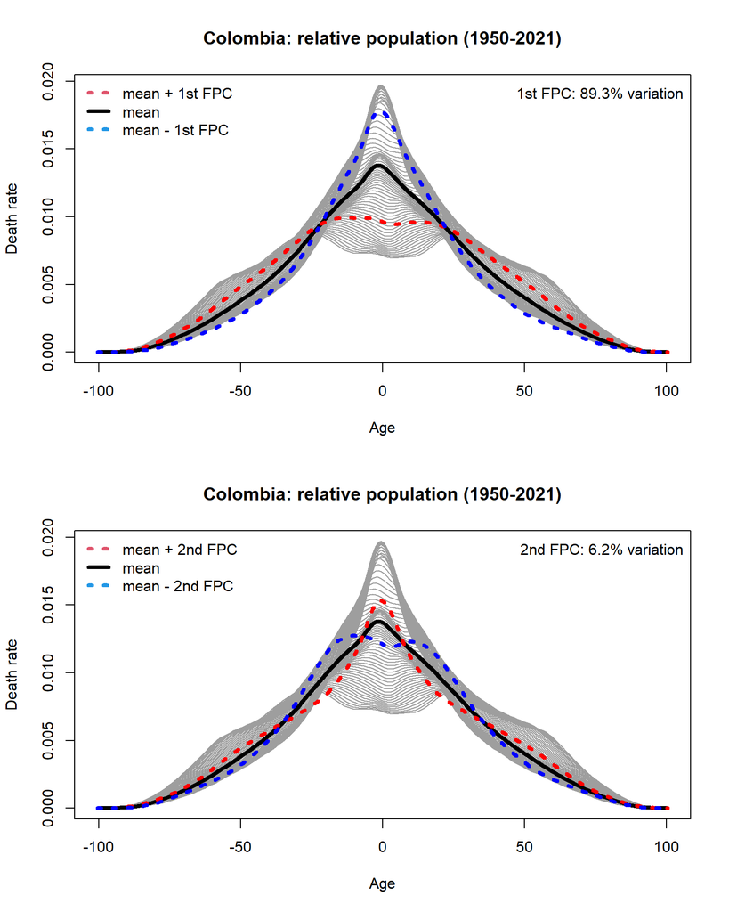

```r
par(mfrow=c(2,1))
plot(ppDemog,col=8,
     main=paste0(Country[ctr,1],": relative population (",Year[1],"-", rev(Year)[1],")"))
lines(ppDemog$age, 1+ppDemog.fit$basis[,1],lwd=4)
eig_val_1 <- var(ppDemog.fit$coeff[,2])
lines(ppDemog$age, 1+ppDemog.fit$basis[,1]+sqrt(eig_val_1)*ppDemog.fit$basis[,2],lwd=4,col="red",lty=3)
lines(ppDemog$age, 1+ppDemog.fit$basis[,1]-sqrt(eig_val_1)*ppDemog.fit$basis[,2],lwd=4,col="blue",lty=3)
legend("topleft",c("mean + 1st FPC ", "mean", "mean - 1st FPC "),
       lty=c(3,1,3), col=c(2,1,4), lwd=4, bty="n",seg.len = 1.5)
legend("topright",paste0("1st FPC: ",round(100*ppDemog.fit$varprop[1],1),"% variation"), bty="n")


plot(ppDemog,col=8,
     main=paste0(Country[ctr,1],": relative population (",Year[1],"-", rev(Year)[1],")"))
lines(ppDemog$age, 1+ppDemog.fit$basis[,1],lwd=4)
eig_val_2 <- var(ppDemog.fit$coeff[,3])
cte=2
lines(ppDemog$age, 1+ppDemog.fit$basis[,1]+cte*sqrt(eig_val_2)*ppDemog.fit$basis[,3],lwd=4,col="red",lty=3)
lines(ppDemog$age, 1+ppDemog.fit$basis[,1]-cte*sqrt(eig_val_2)*ppDemog.fit$basis[,3],lwd=4,col="blue",lty=3)
legend("topleft",c("mean + 2nd FPC ", "mean", "mean - 2nd FPC "),
       lty=c(3,1,3), col=c(2,1,4), lwd=4, bty="n",seg.len = 1.5)
legend("topright",paste0("2nd FPC: ",round(100*ppDemog.fit$varprop[2],1),"% variation"), bty="n")
```

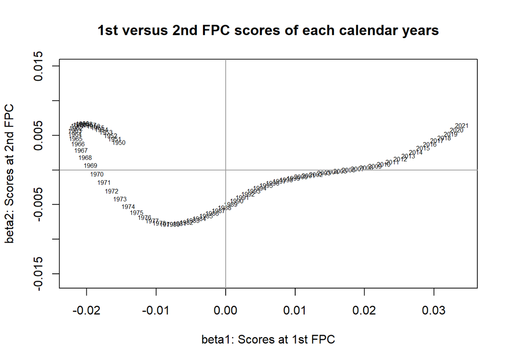

```r
plot(ppDemog.fit$coeff[,2],ppDemog.fit$coeff[,3],type="l",as=1,cex=.5,
     main="1st versus 2nd FPC scores of each calendar years",
     xlab="beta1: Scores at 1st FPC", ylab="beta2: Scores at 2nd FPC")
abline(v=0,h=0,col=8)
```

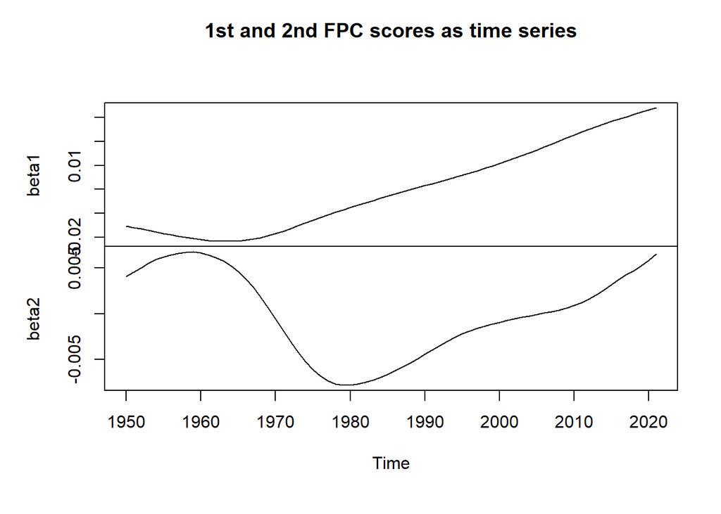

```r
plot(ppDemog.fit$coeff[,2:3], main="1st and 2nd FPC scores as time series")
```

Now, forecasts are computed for a horizon of 20 years:

```r
if (!exists("horiz")) horiz <- 20
ppDemog.fcast <- forecast(ppDemog.fit,h=horiz)
models(ppDemog.fcast)
```

```
##
## -- Coefficient 1 --
## Series: xx[, i]
## ARIMA(3,2,0)
##
## Coefficients:
##          ar1      ar2     ar3
##       1.1301  -0.4578  0.2435
## s.e.  0.1187   0.1838  0.1249
##
## sigma^2 = 7.04e-10:  log likelihood = 639.12
## AIC=-1270.24   AICc=-1269.63   BIC=-1261.25
##
## -- Coefficient 2 --
## Series: xx[, i]
## ARIMA(4,2,0)
##
## Coefficients:
##          ar1      ar2     ar3      ar4
##       1.3604  -0.9875  0.8297  -0.3158
## s.e.  0.1181   0.1972  0.2142   0.1438
##
## sigma^2 = 1.147e-09:  log likelihood = 621.9
## AIC=-1233.8   AICc=-1232.87   BIC=-1222.56
```

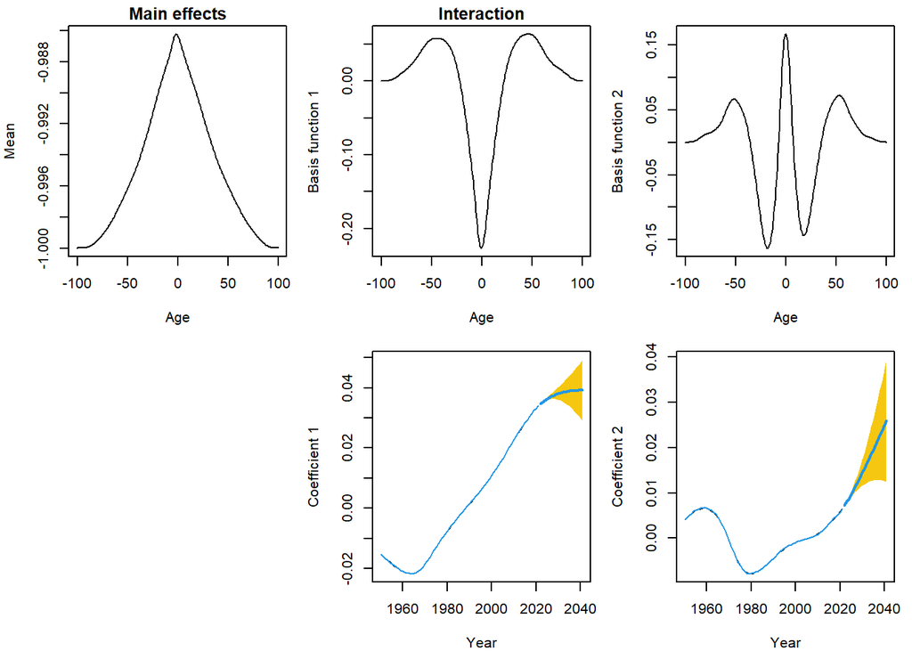

```r
par(mar=c(4,4,1.5,1))
plot(ppDemog.fcast,'c')
```

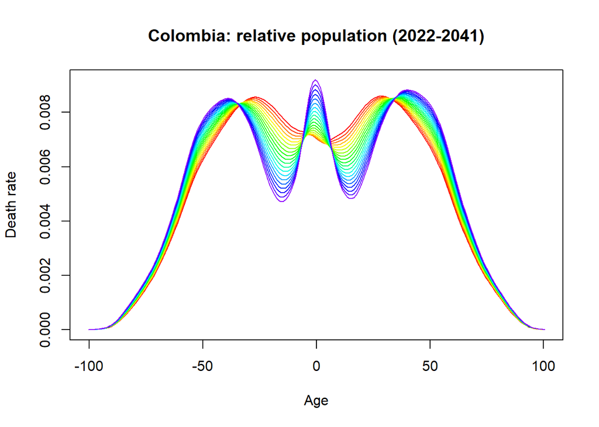

```r
plot(ppDemog.fcast,
     main=paste0(Country[ctr,1],": relative population (",rev(Year)[1]+1,"-", rev(Year)[1]+horiz,")"))
```

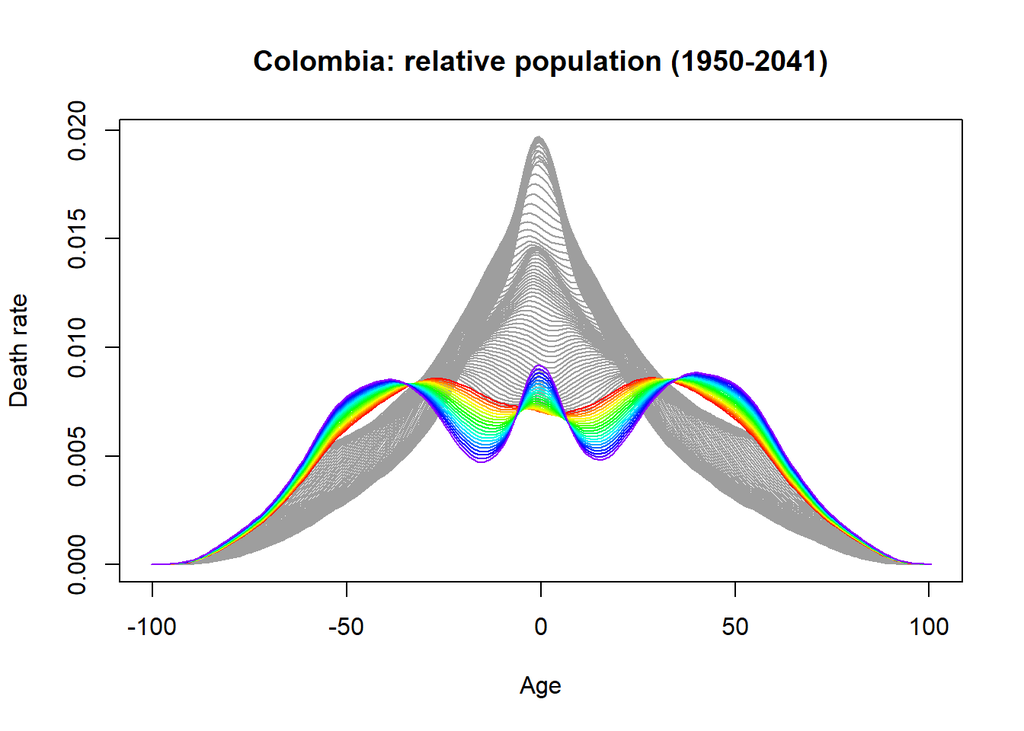

```r
plot(ppDemog, datatype = "rate", col=8,
     main=paste0(Country[ctr,1],": relative population (",Year[1],"-", rev(Year)[1]+horiz,")"))
plot(ppDemog.fcast,add=TRUE)
```

### 2.2.2 Ploting results as population pyramids

We plot now as population pyramids the modeling and forecasting results.

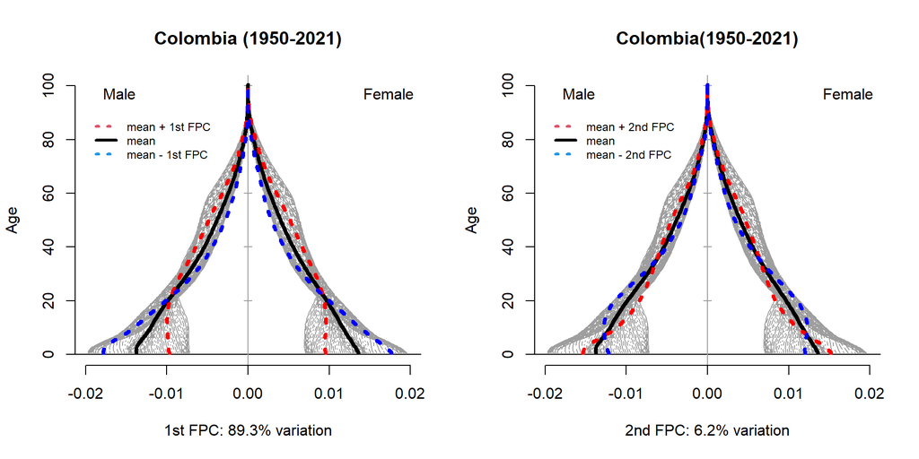

```r
Age.1 <- ppDemog$age[ppDemog$age>0]
par(mfrow=c(1,2))
matplot_pop_pyr_1y(Age.1, t(ppDemog$rate$Total),col=8,
     main=paste0(Country[ctr,1]," (",Year[1],"-", rev(Year)[1],")"))
lines_pop_pyr(Age.1, 1+ppDemog.fit$basis[,1],lwd=4)
eig_val_1 <- var(ppDemog.fit$coeff[,2])
lines_pop_pyr(Age.1, 1+ppDemog.fit$basis[,1]+sqrt(eig_val_1)*ppDemog.fit$basis[,2],lwd=4,col="red",lty=3)
lines_pop_pyr(Age.1, 1+ppDemog.fit$basis[,1]-sqrt(eig_val_1)*ppDemog.fit$basis[,2],lwd=4,col="blue",lty=3)
legend(-0.02, 90,c("mean + 1st FPC ", "mean", "mean - 1st FPC "),
       lty=c(3,1,3), col=c(2,1,4), lwd=3, bty="n",seg.len = 2, cex=.75)
title(xlab=paste0("1st FPC: ",round(100*ppDemog.fit$varprop[1],1),"% variation"), bty="n")

matplot_pop_pyr_1y(Age.1, t(ppDemog$rate$Total),col=8,
     main=paste0(Country[ctr,1],"(",Year[1],"-", rev(Year)[1],")"))
lines_pop_pyr(Age.1, 1+ppDemog.fit$basis[,1],lwd=4)
eig_val_2 <- var(ppDemog.fit$coeff[,3])
cte=2
lines_pop_pyr(Age.1, 1+ppDemog.fit$basis[,1]+cte*sqrt(eig_val_2)*ppDemog.fit$basis[,3],lwd=4,col="red",lty=3)
lines_pop_pyr(Age.1, 1+ppDemog.fit$basis[,1]-cte*sqrt(eig_val_2)*ppDemog.fit$basis[,3],lwd=4,col="blue",lty=3)
legend(-0.02, 90,c("mean + 2nd FPC ", "mean", "mean - 2nd FPC "),
       lty=c(3,1,3), col=c(2,1,4), lwd=3, bty="n",seg.len = 2, cex=.75)

title(xlab=paste0("2nd FPC: ",round(100*ppDemog.fit$varprop[2],1),"% variation"), bty="n")
```

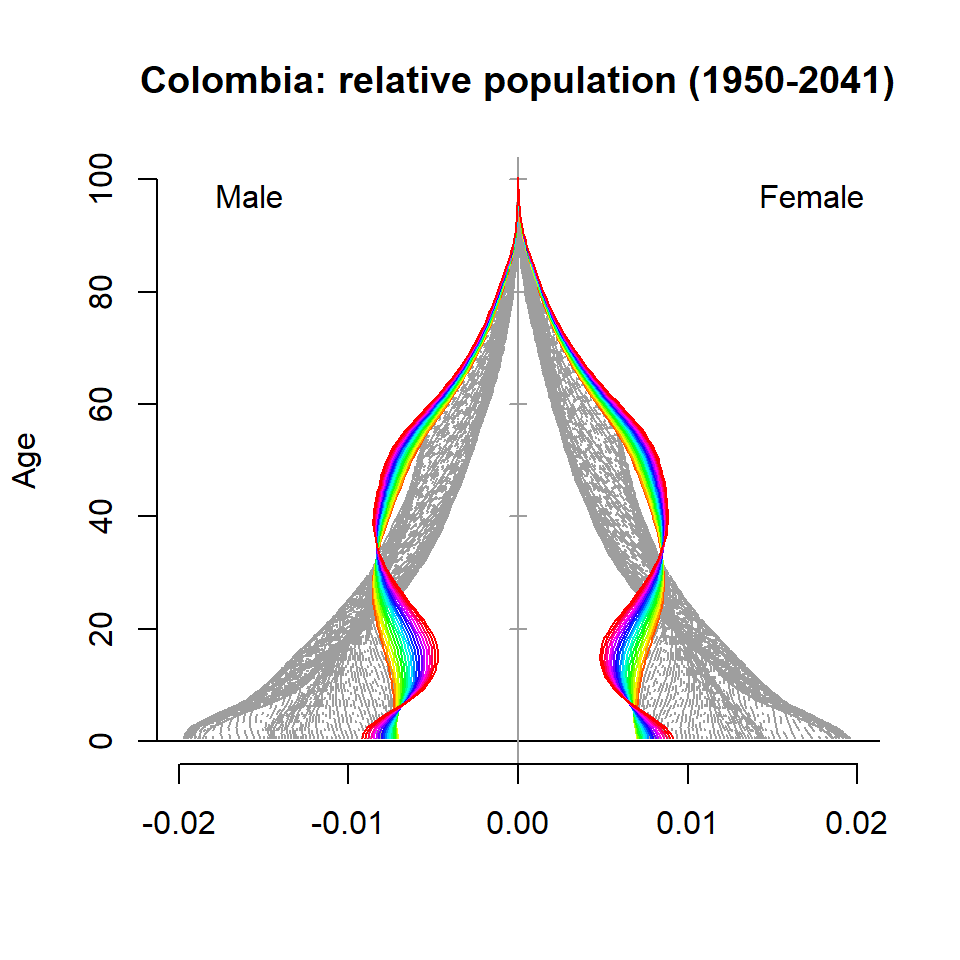

```r
matplot_pop_pyr_1y(Age.1,t(ppDemog$rate$Total), datatype = "rate", col=8,
     main=paste0(Country[ctr,1],
                 ": relative population (",Year[1],"-", rev(Year)[1]+horiz,")"))
col <- rainbow(horiz, start=0, end=1)
for (i in (1:horiz)){
  lines_pop_pyr(Age.1,ppDemog.fcast$rate$total[,i], col=col[i%%length(col)+1])
}
```

## 2.3 Spain, absolute population pyramids

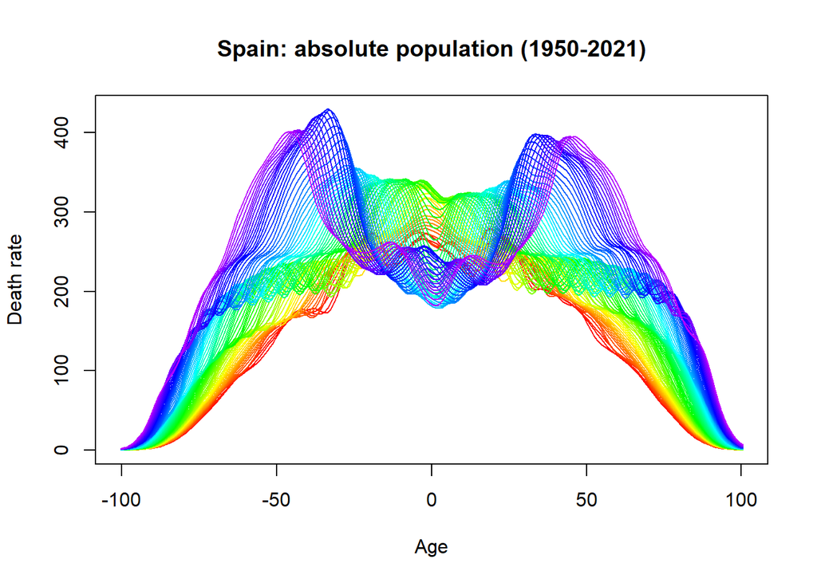

```r
ctr <- 'ES'
ppDemog <- demogdata(data=t(PopPyrSm[ctr,,]),
                     pop=t(PopPyrSm[ctr,,]),
                     ages=egAge.1, years=Year,
                     type= "mortality", label=Country[ctr,1],
                     name="Total", lambda=1)
plot(ppDemog, datatype = "rate", # It is possible to use datatype="pop"
     main=paste0(Country[ctr,1],": absolute population (",Year[1],"-", rev(Year)[1],")"))
```